# TR2

### Let B denote bipartisan matrix(the First one)

### Let P denote partisan matrix(the second one)

### Let F denote full matrix(the third one)

```r
library(readr)
library(ggplot2)
library(dplyr)
```

### The bipartisan matrix

```
##           X99_vote X103_vote X104_vote X105_vote X107_vote X108_vote
## X99_vote       420       336       385       389       408       167
## X103_vote      336       415       363       315       332       209
## X104_vote      385       363       423       365       378       187
## X105_vote      389       315       365       423       388       143
## X107_vote      408       332       378       388       424       164
## X108_vote      167       209       187       143       164       418
```

```
## eigen() decomposition
## $values
## [1] 1983.08474  338.03581  110.18522   41.80931   36.74634   13.13858
##
## $vectors
##            [,1]        [,2]       [,3]        [,4]       [,5]         [,6]
## [1,] -0.4451615 -0.16199937 -0.2170475  0.21181836 -0.2978942  0.771278108
## [2,] -0.4098234  0.11382849  0.7983701 -0.35971436 -0.2275348  0.022948395
## [3,] -0.4418798 -0.05537743  0.2295578  0.60428900  0.6047617 -0.134450238
## [4,] -0.4293867 -0.23032899 -0.3551869 -0.65839440  0.4485097 -0.042116470
## [5,] -0.4430755 -0.17222065 -0.2652616  0.16383832 -0.5404329 -0.620281972
## [6,] -0.2406855  0.93542569 -0.2574441 -0.01572206  0.0228372 -0.001750144
```

```r
bu1<-svd(btb)$u[,1]/norm(svd(btb)$u[,1],'2') #normalized dominate eigenvector
bu2<-svd(btb)$u[,2]/norm(svd(btb)$u[,2], '2') #normalized second eigenvector
btbval <- svd(btb)$d
head(bu1)
```

```
## [1] -0.4451615 -0.4098234 -0.4418798 -0.4293867 -0.4430755 -0.2406855
```

```r
btbval/sum(btbval)
```

```
## [1] 0.786002670 0.133981694 0.043672303 0.016571268 0.014564542 0.005207523
```

In this case, we found that the dominant eigenvector accounts for over 78% of the voting matrix, the second vector account for over 13% of the voting matrix, along with the other eigenvectors that each account for less than 5% of the matrix.

To get v1 and v2:

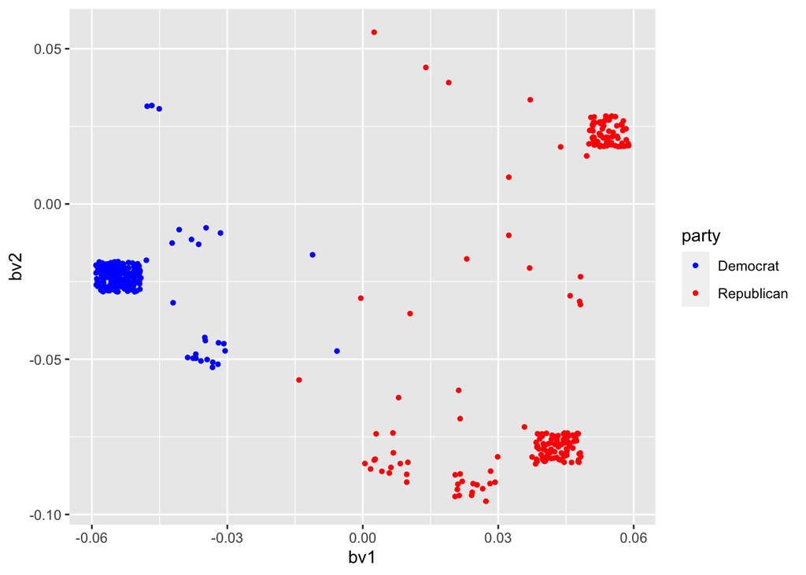

```r
bbt <- B %*% t(B)
bv1 <- eigen(bbt)$vectors[,1]/norm(eigen(bbt)$vectors[,1],'2') #normalized v1
bv2 <- eigen(bbt)$vectors[,2]/norm(eigen(bbt)$vectors[,2],'2') #normalized v2

marijuana <- data.frame(
  name = matrix[1:429,2],
  party = matrix[1:429,3],
  bv1 = bv1,
  bv2 = bv2
)


ggplot() +
  geom_jitter(data = marijuana, aes(x = bv1, y = bv2, color = party),size=1,height=.005,width=.005) +
  scale_color_manual(values = c("Democrat" = "blue", "Republican" = "red"))
```

```r
Bappro <- sqrt(eigen(btb)$values[1]) * bu1 %*% t(bv1) + sqrt(eigen(btb)$values[2]) * bu2 %*% t(bv2)
Bappro
```

### The partisan matrix

```r
P<-as.matrix(matrix[1:429,10:24])
ptp<-t(P)%*%P
ptp
eigen(ptp)

pu1<-svd(ptp)$u[,1]/norm(svd(ptp)$u[,1],'2') #normalized dominate eigenvector
pu2<-svd(ptp)$u[,2]/norm(svd(ptp)$u[,2],'2') #normalized second eigenvector
ptpval <- svd(ptp)$d
```

```r
ptpval/sum(ptpval)
```

```
##  [1] 8.501740e-01 6.617427e-02 6.010030e-02 6.301533e-03 5.383385e-03
##  [6] 2.522980e-03 2.291926e-03 1.928900e-03 1.501108e-03 1.191070e-03
## [11] 9.254548e-04 7.271645e-04 4.806874e-04 2.069587e-04 9.024994e-05
```

To get v1 and v2:

```r
ppt <- P %*% t(P)
pv1 <- eigen(ppt)$vectors[,1]/norm(eigen(ppt)$vectors[,1],'2') #normalized v1
pv2 <- eigen(ppt)$vectors[,2]/norm(eigen(ppt)$vectors[,2],'2') #normalized v2
pv3 <- eigen(ppt)$vectors[,3]/norm(eigen(ppt)$vectors[,3],'2') #normalized v3
controversial <- data.frame(
  name = matrix[1:429,2],
  party = matrix[1:429,3],
  pv1 = pv1,
  pv2 = pv2,
  pv3 = pv3
)
```

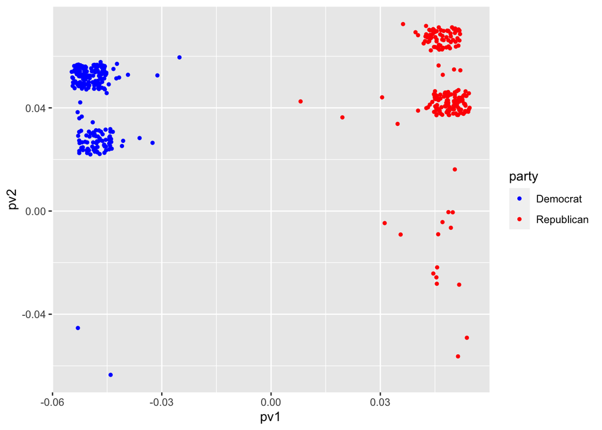

```r
ggplot(controversial,aes(pv1,pv2)) +
  geom_jitter(aes(color = party),size=1,width=.005,height=.005) +
  scale_color_manual(values = c("Democrat" = "blue", "Republican" = "red"))
```

```r
Pappro <- sqrt(eigen(ptp)$values[1]) * pu1 %*% t(pv1) + sqrt(eigen(ptp)$values[2]) * pu2 %*% t(pv2)
Pappro
```

## Are people always in the same cluster? No.

### Partisan matrix(P,controversial): Get names of Republicans in the upper cluster.(72 people)

```r
P_upperRepub <- filter(controversial,controversial$pv1 > 0, controversial$pv2 > 0.06)
#View(P_upperRepub)
P_upperRepub$name
```

```
##  [1] "Rep. Harold “Hal” Rogers [R]"       "Rep. Pete Sessions [R]"
##  [3] "Rep. Michael “Mike” Simpson [R]"    "Rep. Christopher “Chris” Smith [R]"
##  [5] "Rep. Michael Turner [R]"            "Rep. Joe Wilson [R]"
##  [7] "Rep. Virginia Foxx [R]"             "Rep. Michael McCaul [R]"
##  [9] "Rep. Kevin McCarthy [R]"            "Rep. Vern Buchanan [R]"
## [11] "Rep. Tim Walberg [R]"               "Rep. Jim Jordan [R]"
## [13] "Rep. Gus Bilirakis [R]"             "Rep. Steve Scalise [R]"
## [15] "Rep. Brett Guthrie [R]"             "Rep. Blaine Luetkemeyer [R]"
## [17] "Rep. Bill Posey [R]"                "Rep. Glenn Thompson [R]"
## [19] "Rep. Tom Reed [R]"                  "Rep. Daniel Webster [R]"
## [21] "Rep. Austin Scott [R]"              "Rep. Bill Huizenga [R]"
## [23] "Rep. Jeff Duncan [R]"               "Rep. Doug LaMalfa [R]"
## [25] "Rep. David Valadao [R]"             "Rep. Rodney Davis [R]"
## [27] "Rep. Jackie Walorski [R]"           "Rep. Ann Wagner [R]"
## [29] "Rep. Brad Wenstrup [R]"             "Rep. David Joyce [R]"
```

[output cut: 21 more lines]

### Partisan matrix(P,controversial): Get names of Republicans in the lower cluster. (114 people)

```r
P_lowerRepub <- filter(controversial, controversial$pv1 > 0.04, controversial$pv2< 0.05, controversial$pv2 > 0.03)
#View(P_lowerRepub)
P_lowerRepub$name
```

```
##   [1] "Rep. Robert Aderholt [R]"
##   [2] "Rep. Kevin Brady [R]"
##   [3] "Rep. Ken Calvert [R]"
##   [4] "Rep. John Carter [R]"
##   [5] "Rep. Steve Chabot [R]"
##   [6] "Rep. Tom Cole [R]"
##   [7] "Rep. Mario Diaz-Balart [R]"
##   [8] "Rep. Kay Granger [R]"
##   [9] "Rep. Sam Graves [R]"
##  [10] "Rep. Darrell Issa [R]"
##  [11] "Rep. Frank Lucas [R]"
##  [12] "Rep. Mike Rogers [R]"
##  [13] "Rep. Fred Upton [R]"
##  [14] "Rep. Patrick McHenry [R]"
##  [15] "Rep. Louie Gohmert Jr. [R]"
```

[output cut: 99 more lines]

### Bipartisan matrix(B,weed): Get names of Republicans in the upper cluster.(68 people)

```r
B_upperRepub <- filter(marijuana, marijuana$bv1 > 0.045, marijuana$bv2 > 0.018, marijuana$bv2 < 0.03)
#View(B_upperRepub)
B_upperRepub$name
```

```
##  [1] "Rep. Robert Aderholt [R]"        "Rep. Steve Chabot [R]"
##  [3] "Rep. Frank Lucas [R]"            "Rep. Pete Sessions [R]"
##  [5] "Rep. Michael “Mike” Simpson [R]" "Rep. Joe Wilson [R]"
##  [7] "Rep. Virginia Foxx [R]"          "Rep. Louie Gohmert Jr. [R]"
##  [9] "Rep. Vern Buchanan [R]"          "Rep. Jim Jordan [R]"
## [11] "Rep. Robert Latta [R]"           "Rep. Bill Posey [R]"
## [13] "Rep. Paul Gosar [R]"             "Rep. Eric “Rick” Crawford [R]"
## [15] "Rep. Daniel Webster [R]"         "Rep. Bob Gibbs [R]"
## [17] "Rep. Jeff Duncan [R]"            "Rep. David McKinley [R]"
## [19] "Rep. Doug LaMalfa [R]"           "Rep. Jackie Walorski [R]"
## [21] "Rep. Richard Hudson [R]"         "Rep. Brad Wenstrup [R]"
## [23] "Rep. Markwayne Mullin [R]"       "Rep. Scott Perry [R]"
## [25] "Rep. Randy Weber Sr. [R]"        "Rep. Roger Williams [R]"
## [27] "Rep. Gary Palmer [R]"            "Rep. Bruce Westerman [R]"
## [29] "Rep. Rick Allen [R]"             "Rep. David Rouzer [R]"
```

[output cut: 19 more lines]

### Bipartisan matrix(B,weed): Get names of Republicans in the lower cluster.(87 people)

```r
B_lowerRepub <- filter(marijuana, marijuana$bv1 > 0.036, marijuana$bv2 < -0.07, marijuana$bv2 > -0.09)
#View(B_lowerRepub)
B_lowerRepub$name
```

```
##  [1] "Rep. Michael Burgess [R]"
##  [2] "Rep. John Carter [R]"
##  [3] "Rep. Tom Cole [R]"
##  [4] "Rep. Mario Diaz-Balart [R]"
##  [5] "Rep. Kay Granger [R]"
##  [6] "Rep. Darrell Issa [R]"
##  [7] "Rep. Harold “Hal” Rogers [R]"
##  [8] "Rep. Mike Rogers [R]"
##  [9] "Rep. Michael Turner [R]"
## [10] "Rep. Patrick McHenry [R]"
## [11] "Rep. Michael McCaul [R]"
## [12] "Rep. Cathy Rodgers [R]"
## [13] "Rep. Kevin McCarthy [R]"
## [14] "Rep. Tim Walberg [R]"
## [15] "Rep. Gus Bilirakis [R]"
```

[output cut: 72 more lines]

### Get the overlapping names between B’s upper and P’s upper cluster Respublicans(27 people)

```r
intersect(B_upperRepub$name,P_upperRepub$name)
```

```
##  [1] "Rep. Pete Sessions [R]"          "Rep. Michael “Mike” Simpson [R]"
##  [3] "Rep. Joe Wilson [R]"             "Rep. Virginia Foxx [R]"
##  [5] "Rep. Vern Buchanan [R]"          "Rep. Jim Jordan [R]"
##  [7] "Rep. Bill Posey [R]"             "Rep. Daniel Webster [R]"
##  [9] "Rep. Jeff Duncan [R]"            "Rep. Doug LaMalfa [R]"
## [11] "Rep. Jackie Walorski [R]"        "Rep. Brad Wenstrup [R]"
## [13] "Rep. Roger Williams [R]"         "Rep. Gary Palmer [R]"
## [15] "Rep. Elise Stefanik [R]"         "Rep. Brian Babin [R]"
## [17] "Rep. Jim Banks [R]"              "Rep. Mike Gallagher [R]"
## [19] "Rep. Debbie Lesko [R]"           "Rep. Russ Fulcher [R]"
## [21] "Rep. Jefferson Van Drew [R]"     "Rep. Andrew Clyde [R]"
## [23] "Rep. Mary Miller [R]"            "Rep. Matthew Rosendale Sr. [R]"
## [25] "Rep. Scott Fitzgerald [R]"       "Rep. Jake Ellzey [R]"
## [27] "Rep. Mike Carey [R]"
```

### Get the overlapping names between B’s lower and P’s lower cluster Respublicans(50 people)

```r
intersect(B_lowerRepub$name,P_lowerRepub$name)
```

```
##  [1] "Rep. John Carter [R]"
##  [2] "Rep. Tom Cole [R]"
##  [3] "Rep. Mario Diaz-Balart [R]"
##  [4] "Rep. Kay Granger [R]"
##  [5] "Rep. Darrell Issa [R]"
##  [6] "Rep. Mike Rogers [R]"
##  [7] "Rep. Patrick McHenry [R]"
##  [8] "Rep. Mo Brooks [R]"
##  [9] "Rep. David Schweikert [R]"
## [10] "Rep. Steve Womack [R]"
## [11] "Rep. Andy Harris [R]"
## [12] "Rep. Billy Long [R]"
## [13] "Rep. Mike Kelly [R]"
## [14] "Rep. Charles “Chuck” Fleischmann [R]"
## [15] "Rep. Scott DesJarlais [R]"
```

[output cut: 35 more lines]

### Get the overlapping names between B’s upper and P’s lower cluster Respublicans(35 people)

```r
intersect(B_upperRepub$name,P_lowerRepub$name)
```

```
##  [1] "Rep. Robert Aderholt [R]"      "Rep. Steve Chabot [R]"
##  [3] "Rep. Frank Lucas [R]"          "Rep. Louie Gohmert Jr. [R]"
##  [5] "Rep. Robert Latta [R]"         "Rep. Eric “Rick” Crawford [R]"
##  [7] "Rep. Bob Gibbs [R]"            "Rep. David McKinley [R]"
##  [9] "Rep. Richard Hudson [R]"       "Rep. Markwayne Mullin [R]"
## [11] "Rep. Scott Perry [R]"          "Rep. Randy Weber Sr. [R]"
## [13] "Rep. Bruce Westerman [R]"      "Rep. David Rouzer [R]"
## [15] "Rep. Alexander Mooney [R]"     "Rep. Trent Kelly [R]"
## [17] "Rep. David Kustoff [R]"        "Rep. Ralph Norman [R]"
## [19] "Rep. Michael Cloud [R]"        "Rep. Kevin Hern [R]"
## [21] "Rep. John Joyce [R]"           "Rep. William Timmons [R]"
## [23] "Rep. John Rose [R]"            "Rep. Lance Gooden [R]"
## [25] "Rep. Jerry Carl Jr. [R]"       "Rep. Tracey Mann [R]"
## [27] "Rep. Lisa McClain [R]"         "Rep. Michelle Fischbach [R]"
## [29] "Rep. Yvette Herrell [R]"       "Rep. Cliff Bentz [R]"
## [31] "Rep. Diana Harshbarger [R]"    "Rep. Patrick “Pat” Fallon [R]"
## [33] "Rep. Ronny Jackson [R]"        "Rep. Troy Nehls [R]"
## [35] "Rep. Robert “Bob” Good [R]"
```

### Get the overlapping names between B’s lower and P’s upper cluster Respublicans(29 people)

```r
intersect(B_lowerRepub$name,P_upperRepub$name)
```

```
##  [1] "Rep. Harold “Hal” Rogers [R]"      "Rep. Michael Turner [R]"
##  [3] "Rep. Michael McCaul [R]"           "Rep. Kevin McCarthy [R]"
##  [5] "Rep. Tim Walberg [R]"              "Rep. Gus Bilirakis [R]"
##  [7] "Rep. Steve Scalise [R]"            "Rep. Brett Guthrie [R]"
##  [9] "Rep. Blaine Luetkemeyer [R]"       "Rep. Austin Scott [R]"
## [11] "Rep. Bill Huizenga [R]"            "Rep. Chris Stewart [R]"
## [13] "Rep. Jason Smith [R]"              "Rep. Ken Buck [R]"
## [15] "Rep. John Moolenaar [R]"           "Rep. Jack Bergman [R]"
## [17] "Rep. Claudia Tenney [R]"           "Rep. John Curtis [R]"
## [19] "Rep. Michael Waltz [R]"            "Rep. James Baird [R]"
## [21] "Rep. Daniel Meuser [R]"            "Rep. Ben Cline [R]"
## [23] "Rep. Bryan Steil [R]"              "Rep. Fred Keller [R]"
## [25] "Rep. Ashley Hinson [R]"            "Rep. Victoria Spartz [R]"
## [27] "Rep. David “Madison” Cawthorn [R]" "Rep. Andrew Garbarino [R]"
## [29] "Rep. Stephanie Bice [R]"
```

## If we scale controversial_k

```r
controversial_k<-controversial%>%
  select(pv1,pv2,pv3)
set.seed(169)
kclust_controversial<-kmeans(scale(controversial_k),centers=3)

head(kclust_controversial)
```

```
## $cluster
##   [1] 2 1 1 2 2 2 2 1 2 1 2 1 1 1 1 1 2 1 1 1 2 2 1 1 2 1 1 1 1 1 1 1 1 1 2 1 1
##  [38] 1 1 1 1 1 1 1 1 1 1 2 3 1 1 1 1 1 1 1 1 1 3 1 3 1 3 1 1 2 3 1 1 3 1 1 1 1
##  [75] 1 2 2 3 1 3 2 3 1 1 1 1 1 2 3 1 1 1 3 1 1 1 2 3 1 3 1 1 2 2 3 1 1 1 3 1 3
## [112] 1 1 2 3 1 3 1 3 1 1 1 1 1 1 2 3 2 2 2 2 3 1 3 1 2 2 2 3 1 2 2 2 2 2 2 3 1
## [149] 2 2 2 2 2 2 3 2 3 1 1 3 1 1 1 3 1 1 1 1 1 1 1 1 1 3 1 2 3 1 2 3 1 1 1 1 1
## [186] 3 1 2 2 3 2 2 3 1 3 1 3 1 1 1 3 1 1 1 2 2 3 1 1 1 1 1 2 2 2 3 2 2 3 1 3 1
## [223] 1 2 3 1 3 1 2 3 1 3 1 2 2 2 2 2 2 3 1 2 3 1 1 1 1 1 2 2 2 3 1 1 1 1 1 2 3
## [260] 1 2 2 2 3 1 1 2 2 3 1 1 1 2 2 2 3 1 3 1 1 2 2 2 3 1 3 1 2 2 2 3 1 1 1 1 1
## [297] 1 1 1 1 1 2 3 1 1 3 1 1 1 2 3 1 1 1 1 1 1 1 1 1 3 1 3 2 3 1 3 1 1 1 1 1 1
## [334] 3 1 1 2 2 2 2 2 2 2 2 2 2 3 1 2 3 1 1 1 3 1 1 1 2 3 1 3 2 2 2 2 2 2 2 2 2
## [371] 3 1 2 2 2 2 2 3 1 1 3 3 1 2 2 3 1 3 1 2 2 3 1 2 2 3 1 3 1 1 2 3 1 2 3 1 1
## [408] 1 2 2 2 2 2 2 2 2 2 2 2 2 3 1 2 3 1 1 3 1 3
##
## $centers
##          pv1        pv2        pv3
## 1 -0.3118390  0.6774491  0.8988343
## 2  1.0342933 -0.3647511 -0.6620394
## 3 -0.8506088 -1.1322300 -1.2202576
##
## $totss
## [1] 1284
##
## $withinss
## [1] 234.4262 139.3696 109.2130
##
## $tot.withinss
## [1] 483.0089
##
## $betweenss
## [1] 800.9911
```

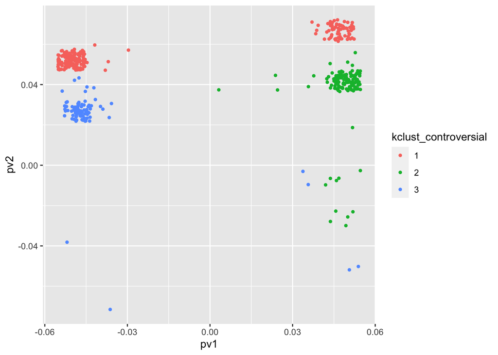

```r
controversial<-controversial%>%
  mutate(kclust_controversial=as.factor(kclust_controversial$cluster))
ggplot(controversial,aes(pv1,pv2)) +
  geom_jitter(aes(color = kclust_controversial),size=1,width=.005,height=.005)
```

```r
controversial$pv3
```

```
##   [1] -4.907350e-02  2.236911e-02  2.236911e-02 -4.907350e-02 -3.679420e-02
##   [6] -4.907350e-02 -4.907350e-02  2.236911e-02 -4.907350e-02  2.236911e-02
##  [11] -4.907350e-02  2.236911e-02  2.236911e-02  2.236911e-02  2.236911e-02
##  [16]  2.236911e-02 -4.907350e-02  2.236911e-02  2.236911e-02  2.236911e-02
##  [21] -4.907350e-02 -4.907350e-02  2.236911e-02  2.236911e-02 -4.907350e-02
##  [26]  2.236911e-02  2.236911e-02  2.236911e-02  2.236911e-02  2.236911e-02
##  [31]  2.236911e-02  2.236911e-02  2.236911e-02  2.236911e-02 -4.907350e-02
##  [36]  2.236911e-02  2.236911e-02  2.236911e-02  2.236911e-02  2.236911e-02
##  [41]  2.236911e-02  2.236911e-02  2.236911e-02  2.236911e-02  2.236911e-02
##  [46]  2.236911e-02  4.925474e-02 -4.907350e-02 -2.679501e-02  2.236911e-02
##  [51]  2.236911e-02  2.236911e-02  2.236911e-02  2.236911e-02  2.236911e-02
##  [56]  2.236911e-02  2.236911e-02  4.925474e-02 -7.595914e-02  4.925474e-02
##  [61] -7.595914e-02  4.925474e-02 -7.595914e-02  2.236911e-02  4.925474e-02
##  [66] -4.907350e-02 -7.595914e-02  2.236911e-02  4.839530e-02 -7.595914e-02
##  [71]  2.236911e-02  2.236911e-02  2.236911e-02  2.236911e-02  4.925474e-02
```

[output cut: 71 more lines]

## If we don’t scale controversial_k

```r
kclust_controversial2<-kmeans(controversial_k,centers=3)
head(kclust_controversial2)
```

```
## $cluster
##   [1] 1 2 2 1 1 1 1 2 1 2 1 2 2 2 2 2 1 2 2 2 1 1 2 2 1 2 2 2 2 2 2 2 2 2 1 2 2
##  [38] 2 2 2 2 2 2 2 2 2 1 1 3 2 2 2 2 2 2 2 2 1 3 1 3 1 3 2 1 1 3 2 1 3 2 2 2 2
##  [75] 1 1 1 3 1 3 1 3 2 2 2 2 1 1 3 2 2 1 3 2 2 1 1 3 1 3 2 1 1 1 3 2 2 1 3 1 3
## [112] 2 1 1 3 1 3 1 3 2 2 2 2 2 1 1 3 1 1 1 1 3 1 3 1 3 1 1 3 1 1 1 1 1 1 1 3 1
## [149] 1 1 1 1 1 1 3 1 3 2 1 3 2 2 1 3 2 2 2 2 2 2 2 2 1 3 1 1 3 1 1 3 2 2 2 2 1
## [186] 3 1 1 1 3 1 1 3 1 3 1 3 2 2 1 3 2 2 1 1 1 3 2 2 2 2 1 1 1 1 1 1 1 3 1 3 2
## [223] 1 1 3 1 3 1 1 3 1 3 1 1 1 1 1 1 1 3 2 1 3 2 2 2 2 2 1 1 1 3 2 2 2 2 1 1 3
## [260] 1 1 1 1 3 2 1 1 1 3 2 2 1 1 1 1 3 1 3 2 1 1 1 1 3 1 3 1 1 1 1 3 2 2 2 2 2
## [297] 2 2 2 2 1 1 3 2 1 3 2 2 1 1 3 2 2 2 2 2 2 2 2 2 2 1 1 1 3 1 3 2 2 2 2 2 1
## [334] 3 2 1 1 1 1 1 1 1 1 1 1 1 3 2 1 3 2 2 1 2 2 2 1 1 3 1 1 1 1 1 1 1 1 1 1 1
## [371] 3 1 1 1 1 1 1 3 2 1 1 3 1 1 1 3 1 3 1 1 1 3 1 1 1 3 1 3 2 1 1 3 1 1 3 2 2
## [408] 1 1 1 1 1 1 1 1 1 1 1 1 1 3 1 1 3 2 1 3 1 3
##
## $centers
##           pv1        pv2         pv3
## 1  0.04763906 0.04651656 -0.01018506
## 2 -0.04958014 0.05142095  0.02238757
## 3 -0.04664838 0.02665257 -0.07215449
##
## $totss
## [1] 2.099427
##
## $withinss
## [1] 0.58331194 0.01306392 0.02490543
##
## $tot.withinss
## [1] 0.6212813
##
## $betweenss
## [1] 1.478146
```

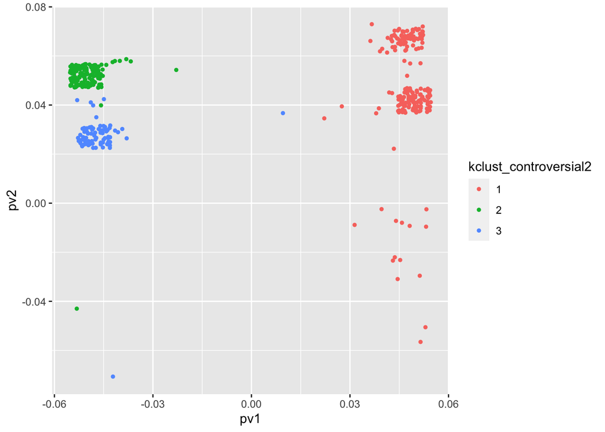

```r
controversial<-controversial%>%
  mutate(kclust_controversial2=as.factor(kclust_controversial2$cluster))
ggplot(controversial,aes(pv1,pv2)) +
  geom_jitter(aes(color = kclust_controversial2),size=1,width=.005,height=.005)
```

```r
controversial$pv3
```

```
##   [1] -4.907350e-02  2.236911e-02  2.236911e-02 -4.907350e-02 -3.679420e-02
##   [6] -4.907350e-02 -4.907350e-02  2.236911e-02 -4.907350e-02  2.236911e-02
##  [11] -4.907350e-02  2.236911e-02  2.236911e-02  2.236911e-02  2.236911e-02
##  [16]  2.236911e-02 -4.907350e-02  2.236911e-02  2.236911e-02  2.236911e-02
##  [21] -4.907350e-02 -4.907350e-02  2.236911e-02  2.236911e-02 -4.907350e-02
##  [26]  2.236911e-02  2.236911e-02  2.236911e-02  2.236911e-02  2.236911e-02
##  [31]  2.236911e-02  2.236911e-02  2.236911e-02  2.236911e-02 -4.907350e-02
##  [36]  2.236911e-02  2.236911e-02  2.236911e-02  2.236911e-02  2.236911e-02
##  [41]  2.236911e-02  2.236911e-02  2.236911e-02  2.236911e-02  2.236911e-02
##  [46]  2.236911e-02  4.925474e-02 -4.907350e-02 -2.679501e-02  2.236911e-02
##  [51]  2.236911e-02  2.236911e-02  2.236911e-02  2.236911e-02  2.236911e-02
##  [56]  2.236911e-02  2.236911e-02  4.925474e-02 -7.595914e-02  4.925474e-02
##  [61] -7.595914e-02  4.925474e-02 -7.595914e-02  2.236911e-02  4.925474e-02
##  [66] -4.907350e-02 -7.595914e-02  2.236911e-02  4.839530e-02 -7.595914e-02
##  [71]  2.236911e-02  2.236911e-02  2.236911e-02  2.236911e-02  4.925474e-02
```

[output cut: 71 more lines]

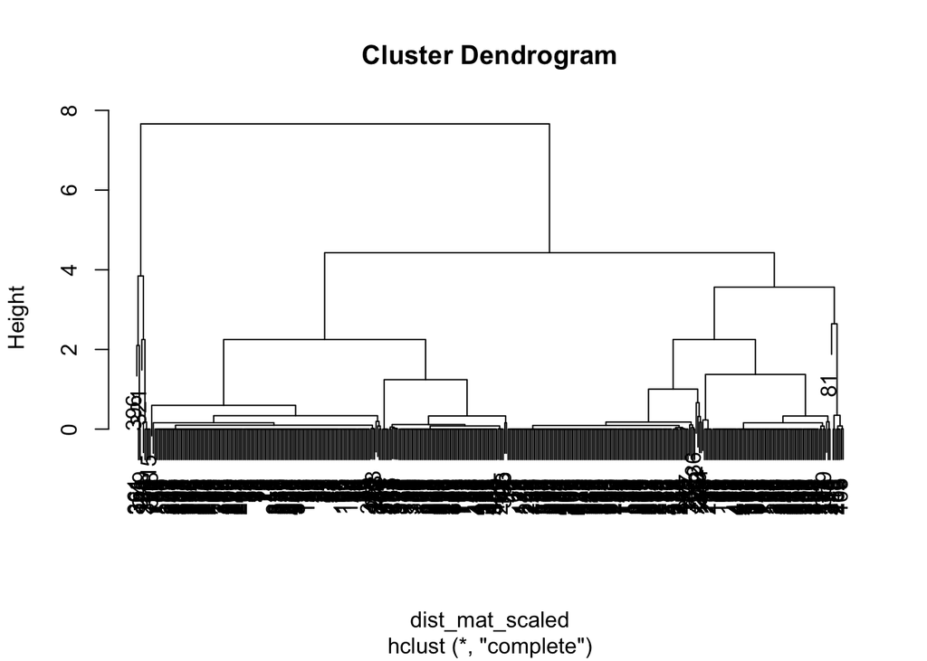

```r
dist_mat_scaled<-dist(scale(controversial_k))
hc_complete<-hclust(dist_mat_scaled,method="complete")
plot(hc_complete)
```

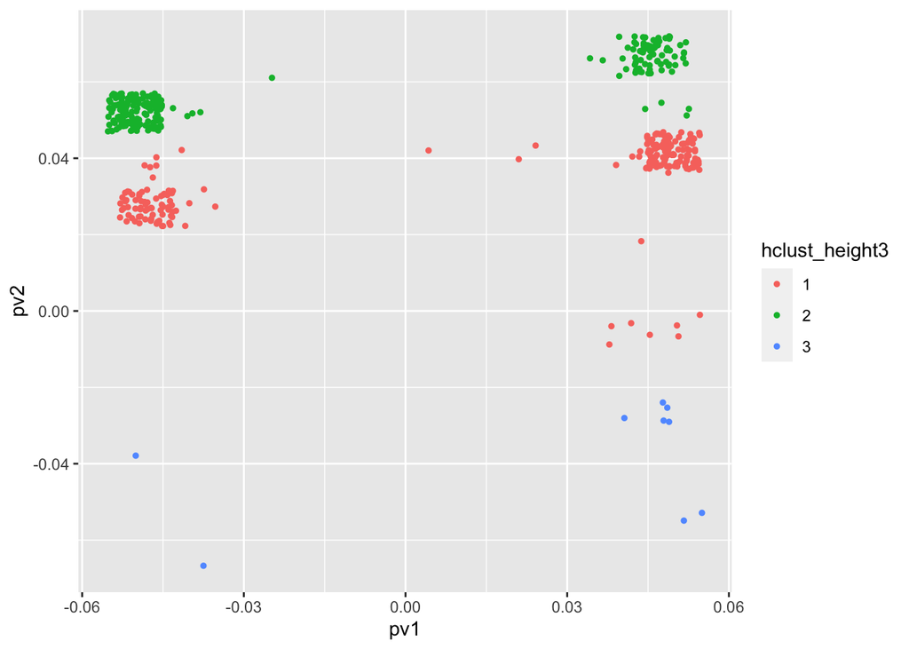

```r
controversial<-controversial%>%
  mutate(hclust_height3=factor(cutree(hc_complete,h=4)))
ggplot(controversial,aes(pv1,pv2)) +
  geom_jitter(aes(color = hclust_height3),size=1,width=.005,height=.005)
```

```r
Ful<-as.matrix(matrix[1:429,4:24])
ftf<-t(Ful)%*%Ful
ftf
```

```
##           X99_vote X103_vote X104_vote X105_vote X107_vote X108_vote X125_vote
## X99_vote       420       336       385       389       408       167        34
## X103_vote      336       415       363       315       332       209        89
## X104_vote      385       363       423       365       378       187        63
## X105_vote      389       315       365       423       388       143         9
## X107_vote      408       332       378       388       424       164        30
## X108_vote      167       209       187       143       164       418       263
## X125_vote       34        89        63         9        30       263       421
## X22_vote       399       329       376       386       397       151        22
## X30_vote      -419      -338      -388      -394      -413      -165       -30
## vote_18        415       338       388       390       409       165        30
## vote_36        420       339       389       395       413       167        30
## vote_31        416       337       385       395       408       166        31
## vote_74        414       334       382       392       408       164        31
## vote_120       414       334       384       394       407       163        28
## vote_81        418       336       386       396       416       168        28
## vote_116       416       335       385       391       410       163        29
## vote_118       414       333       383       389       406       165        33
## vote_123       398       333       383       377       390       169        34
## vote_43        410       349       395       385       402       176        41
## vote_64        407       336       378       384       400       166        36
## vote_10        112        84        98        98       123        38        19
##           X22_vote X30_vote vote_18 vote_36 vote_31 vote_74 vote_120 vote_81
## X99_vote       399     -419     415     420     416     414      414     418
## X103_vote      329     -338     338     339     337     334      334     336
## X104_vote      376     -388     388     389     385     382      384     386
## X105_vote      386     -394     390     395     395     392      394     396
## X107_vote      397     -413     409     413     408     408      407     416
## X108_vote      151     -165     165     167     166     164      163     168
## X125_vote       22      -30      30      30      31      31       28      28
## X22_vote       426     -408     408     407     403     404      405     405
## X30_vote      -408      428    -424    -427    -423    -420     -421    -425
## vote_18        408     -424     428     423     419     416      417     421
## vote_36        407     -427     423     428     424     421      422     425
## vote_31        403     -423     419     424     427     417      418     420
## vote_74        404     -420     416     421     417     423      419     418
## vote_120       405     -421     417     422     418     419      424     419
## vote_81        405     -425     421     425     420     418      419     428
## vote_116       404     -424     420     424     419     417      420     422
## vote_118       398     -418     414     420     417     413      416     416
```

[output cut: 11 more lines]

```
## X125_vote       29       33       34      41      36      19
## X22_vote       404      398      392     404     396     110
## X30_vote      -424     -418     -404    -416    -414    -116
## vote_18        420      414      408     416     410     116
## vote_36        424      420      406     418     415     116
## vote_31        419      417      407     415     411     111
## vote_74        417      413      399     411     408     111
## vote_120       420      416      402     412     409     112
## vote_81        422      416      402     414     412     120
## vote_116       425      417      403     413     411     115
## vote_118       417      423      401     411     407     111
## vote_123       403      401      425     409     393     111
## vote_43        413      411      409     429     405     113
## vote_64        411      407      393     405     419     113
## vote_10        115      111      111     113     113     419
```

```r
eigen(ftf)
```

```
## eigen() decomposition
## $values
##  [1] 7318.7554770  652.8016523  388.8888913  144.1082231  123.1554665
##  [6]   54.2636353   47.2318403   35.5806928   32.0590224   22.0281257
## [11]   15.3635565   13.1259839   11.4516446    9.5897407    7.6164293
## [16]    6.4925999    5.4837519    3.3222091    2.8799614    1.2441931
## [21]    0.5569028
##
## $vectors
##              [,1]         [,2]         [,3]        [,4]         [,5]
##  [1,] -0.23693155  0.026227327  0.014922051 -0.06703334 -0.028776448
##  [2,] -0.19941151 -0.159540355  0.052680466  0.66075323  0.526956699
##  [3,] -0.22462762 -0.060385738  0.042810571  0.26343260  0.287763492
##  [4,] -0.22511449  0.072084194  0.041561089 -0.04534548 -0.054996521
##  [5,] -0.23411965  0.032067802 -0.018240233 -0.05392288 -0.046929869
```

[output cut: 104 more lines]

```r
fu1<-svd(ftf)$u[,1]/norm(svd(ftf)$u[,1],'2') #normalized dominate eigenvector
fu2<-svd(ftf)$u[,2]/norm(svd(ftf)$u[,2],'2') #normalized second eigenvector
ftfval <- svd(ftf)$d
head(fu1)
```

```
## [1] -0.2369316 -0.1994115 -0.2246276 -0.2251145 -0.2341197 -0.1032973
```

```r
ftfval/sum(ftfval)
```

```
##  [1] 8.227018e-01 7.338148e-02 4.371503e-02 1.619922e-02 1.384391e-02
##  [6] 6.099779e-03 5.309335e-03 3.999628e-03 3.603757e-03 2.476183e-03
## [11] 1.727018e-03 1.475493e-03 1.287280e-03 1.077983e-03 8.561634e-04
## [16] 7.298336e-04 6.164289e-04 3.734498e-04 3.237367e-04 1.398598e-04
## [21] 6.260148e-05
```

```r
fft <- Ful %*% t(Ful)
fv1 <- eigen(fft)$vectors[,1]/norm(eigen(fft)$vectors[,1],'2') #normalized v1
fv1
```

```
##   [1]  0.050866496 -0.051453177 -0.051453177  0.046889524  0.046006660
##   [6]  0.043789704  0.048451589 -0.046190402  0.050866496 -0.051453177
##  [11]  0.048451589 -0.051453177 -0.051453177 -0.051453177 -0.051453177
##  [16] -0.051453177  0.048451589 -0.051453177 -0.051453177 -0.051453177
##  [21]  0.048451589  0.043789704 -0.050245724 -0.051453177  0.048451589
##  [26] -0.051453177 -0.051453177 -0.051453177 -0.051453177 -0.051453177
##  [31] -0.051453177 -0.051453177 -0.051453177 -0.051453177  0.050866496
##  [36] -0.051453177 -0.051453177 -0.051453177 -0.051453177 -0.050245724
##  [41] -0.050245724 -0.051453177 -0.051453177 -0.051453177 -0.051453177
##  [46] -0.051453177  0.046856877  0.048451589 -0.050655822 -0.051453177
##  [51] -0.051453177 -0.051453177 -0.051453177 -0.051453177 -0.051453177
##  [56] -0.051453177 -0.051453177  0.049271785 -0.049858466  0.049271785
##  [61] -0.049858466  0.042194992 -0.049858466 -0.051453177  0.046856877
##  [66]  0.038538311 -0.049858466 -0.051453177  0.046480801 -0.049858466
##  [71] -0.051453177 -0.051453177 -0.051453177 -0.051453177  0.049271785
```

[output cut: 71 more lines]

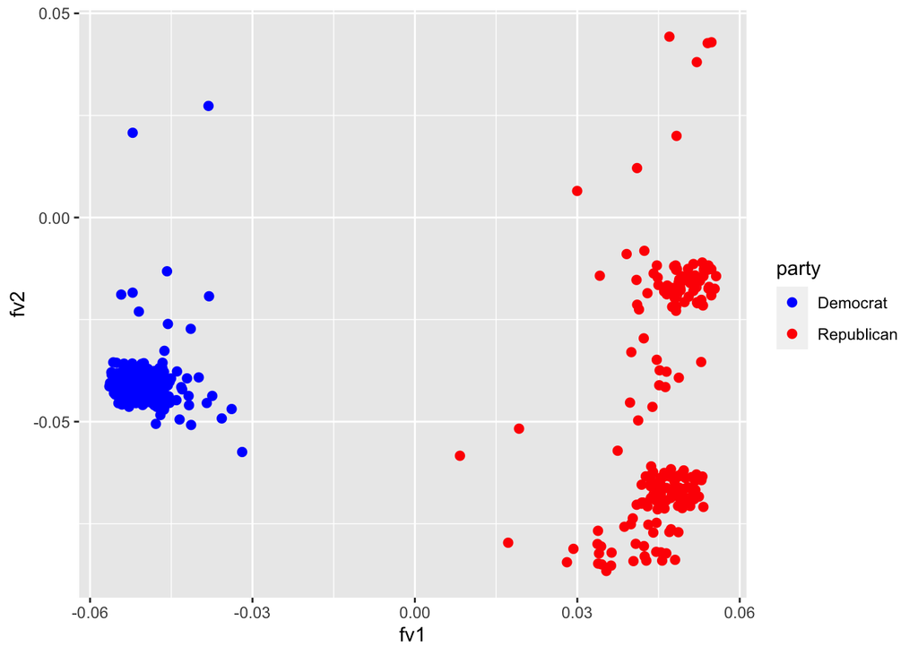

```r
fv2 <- eigen(fft)$vectors[,2]/norm(eigen(fft)$vectors[,2],'2') #normalized v2

full <- data.frame(
  party = matrix[1:429,3],
  fv1 = fv1,
  fv2 = fv2
)


ggplot() +
  geom_jitter(data = full, aes(x = fv1, y = fv2, color = party,label=controversial$name),size=2,width=.005,height=.005)+
  geom_text()+
  scale_color_manual(values = c("Democrat" = "blue", "Republican" = "red"))
```

```r
Fappro <- sqrt(eigen(ftf)$values[1]) * fu1 %*% t(fv1) + sqrt(eigen(ftf)$values[2]) * fu2 %*% t(fv2)
Fappro
```